# Compare Salmon Network Stats Across Ports

Preparation for network analysis for CCIEA SSC-ES meeting September 2022, ESR 2023

J. Samhouri

Written Sep 14, 2022. Last Run 2023-03-04

# Description

This document graphs network metrics for salmon alongside revenue by port groups.

# Setup

This script requires the following packages.

Select your directories.

What are the names of the `.csv` files with the network statistics that you want to compare? Would not suggest listing more than 4. Files should all be in the input directory (`indir`) specified above.

```r
filenames <- c("VesselLevelNodeStats_2004_2020_21pcgroups_totalrev5000_indivrev500_connectivity_rmCrab_10pContribution.csv")

networkstats_filename <- "VesselLevelNetworkStats_2004_2020_21pcgroups_totalrev5000_indivrev500_connectivity_rmCrab_10pContribution.csv"

port_filename <- 'iopac_conversion_table.csv'

tix_filenames <- c(
  'fish_tickets_crab2004_processed_for_networks.csv',
  'fish_tickets_crab2005_processed_for_networks.csv',
  'fish_tickets_crab2007_processed_for_networks.csv',
  'fish_tickets_crab2008_processed_for_networks.csv',
  'fish_tickets_crab2009_processed_for_networks.csv',
  'fish_tickets_crab2010_processed_for_networks.csv',
  'fish_tickets_crab2011_processed_for_networks.csv',
  'fish_tickets_crab2012_processed_for_networks.csv',
  'fish_tickets_crab2013_processed_for_networks.csv',
  'fish_tickets_crab2014_processed_for_networks.csv',
  'fish_tickets_crab2015_processed_for_networks.csv',
  'fish_tickets_crab2016_processed_for_networks.csv',
  'fish_tickets_crab2017_processed_for_networks.csv',
  'fish_tickets_crab2018_processed_for_networks.csv',
  'fish_tickets_crab2019_processed_for_networks.csv',
  'fish_tickets_crab2020_processed_for_networks.csv'
  )
```

Provide descriptive names to differentiate the datasets drawn from the files listed above.

Specify which network metrics and fish tix info to retain from the full data set.

```r
node_metrics <- c('node_strength','eigen')
node_metrics_scaled <- c('node_strength_scaled','node_strength_ltmean','ma_node_strength','eigen_scaled', 'eigen_ltmean', 'ma_eigen')

network_metrics <- c('ed') # ,'ed_weighted'
network_metrics_scaled <- c('ed_scaled','ed_ltmean', 'ma_ed')

landings_metrics <- c('adjrev', 'ma_adjrev','pounds',
                    'ma_pounds')
landings_metrics_scaled <- c('adjrev_scaled','adjrev_ltmean','ma_adjrev_scaled', 'pounds_scaled','pounds_ltmean','ma_pounds_scaled')
```

Specify which fisheries to retain from the full data set and whether to calculate moving average for sensitivity/economic dependence.

```r
myfisheries <- c('Salmon')
my_spgroup <- c(30)
# how long should the moving average sensitivity be calculated over?
salmon_moving_average <- 5
```

Specify IOPAC port groups to retain from the full data set, and read them in. Focus on all except ‘Unknown Ports’

# Read in Data

Network metrics from different datasets.

```r
for(i in seq(1,length(filenames))){
  tmpdat <- read.csv(here::here(indir, filenames[i])) %>%
    dplyr::select(pcgroup, year, metier.cm, all_of(node_metrics)) %>%
    filter(pcgroup %in% all_iopac) %>%
    filter(metier.cm %in% myfisheries) %>%
    mutate(dataset=dataset_names[i])
  if(i==1){
    dat <- tmpdat
  } else{ dat <- bind_rows(dat,tmpdat)}
}

dat <- dat %>% distinct() # remove duplicated WA Coast entries
glimpse(dat)
```

```
## Rows: 227
## Columns: 6
## $ pcgroup       <chr> "Puget Sound", "North WA Coast", "WA Coast", "Other Coas…
## $ year          <int> 2004, 2004, 2004, 2004, 2004, 2004, 2004, 2004, 2004, 20…
## $ metier.cm     <chr> "Salmon", "Salmon", "Salmon", "Salmon", "Salmon", "Salmo…
## $ node_strength <dbl> 0.08796892, 0.11580228, 0.09779177, NaN, 0.03404752, 0.5…
## $ eigen         <dbl> 0.03859436, 0.15441887, 0.12324317, 1.00000000, 0.014686…
## $ dataset       <chr> "NodeStats", "NodeStats", "NodeStats", "NodeStats", "Nod…
```

```r
for(i in seq(1,length(networkstats_filename))){
  tmpdat2 <- read.csv(here::here(indir, networkstats_filename[i])) %>%
    dplyr::select(pcgroup, y, all_of(network_metrics)) %>%
    #filter(pcgroup %in% myports) %>%
    #filter(metier.cm %in% myfisheries) %>%
    mutate(dataset=dataset_names2[i])
  if(i==1){
    dat2 <- tmpdat2
  } else{ dat2 <- bind_rows(dat2,tmpdat2)}
}

dat2 <- dat2 %>% distinct() # remove duplicated WA Coast entries
glimpse(dat2)
```

```
## Rows: 348
## Columns: 4
## $ pcgroup <chr> "Puget Sound", "North WA Coast", "WA Coast", "Other Coastal Wa…
## $ y       <int> 2004, 2004, 2004, 2004, 2004, 2004, 2004, 2004, 2004, 2004, 20…
## $ ed      <dbl> 0.3090909, 0.5238095, 0.6785714, NA, 0.6388889, 0.4761905, 1.0…
## $ dataset <chr> "Network_Stats", "Network_Stats", "Network_Stats", "Network_St…
```

Revenue and landings from different datasets.

```r
for(i in seq(1,length(tix_filenames))){
  tmpdat3 <- read.csv(paste0(indir3, tix_filenames[i])) %>%
    #dplyr::select(pcgroup, year, metier.cm, all_of(node_metrics)) %>%
    filter(IOPAC %in% all_iopac) %>%
    filter(SPGRPN2 %in% my_spgroup) %>%
    group_by(crab_year, IOPAC, SPGRPN2) %>%
    summarise(
      adjrev = sum(adj_revenue, na.rm=TRUE), # may want to remove na.rm
      pounds = sum(pounds, na.rm=TRUE), # may want to remove na.rm
      num_vessels = length(unique(drvid)),
      .groups = "drop"
    ) %>%
    mutate(
      metier.cm = "Salmon"
    )
    #mutate(dataset=dataset_names[i])
  if(i==1){
    dat3 <- tmpdat3
  } else{ dat3 <- bind_rows(dat3,tmpdat3)}
}

glimpse(dat3)
```

```
## Rows: 265
## Columns: 7
## $ crab_year   <int> 2004, 2004, 2004, 2004, 2004, 2004, 2004, 2004, 2004, 2004…
## $ IOPAC       <chr> "Astoria", "Bodega Bay", "Brookings", "Columbia River", "C…
## $ SPGRPN2     <int> 30, 30, 30, 30, 30, 30, 30, 30, 30, 30, 30, 30, 30, 30, 30…
## $ adjrev      <dbl> 452398.350, 1672912.830, 796739.650, 1592173.336, 3214798.…
## $ pounds      <dbl> 145091, 569814, 247524, 1252744, 1054506, 25045, 84260, 90…
## $ num_vessels <int> 71, 221, 90, 185, 301, 31, 62, 215, 283, 72, 306, 55, 8, 2…
## $ metier.cm   <chr> "Salmon", "Salmon", "Salmon", "Salmon", "Salmon", "Salmon"…
```

Check to make sure that all of the datasets were read in.

Convert metrics into anomalies from long-term means. Use scale() to standardize metrics. Standardization should be relative to values observed for each port

```r
#Scale() does not alter the distribution shape
# ggplot(dat) + geom_histogram(aes(node_strength)) + theme_classic()
# ggplot(dat) + geom_histogram(aes(scale(node_strength))) + theme_classic()

dat <- dat %>%
  group_by(pcgroup) %>%
  mutate(
    node_strength_scaled = as.numeric(scale(node_strength)),
    node_strength_ltmean = attr(scale(node_strength),"scaled:center"),
    eigen_scaled = as.numeric(scale(eigen)),
    eigen_ltmean = attr(scale(eigen),"scaled:center") # note because we use scale() mutated varables return as matrices
  ) %>%
  arrange(year) %>%
  group_by(pcgroup) %>%
  mutate(
    ma_node_strength=rollapply(node_strength,width=salmon_moving_average,mean,align='right',fill=NA),
    ma_eigen=rollapply(eigen,width=salmon_moving_average,mean,align='right',fill=NA)
  )


dat2 <- dat2 %>%
  group_by(pcgroup) %>%
  mutate(
    ed_scaled = as.numeric(scale(ed)),
    ed_ltmean = attr(scale(ed),"scaled:center")
  ) %>%
  arrange(y) %>%
  group_by(pcgroup) %>%
  mutate(
    ma_ed=rollapply(ed,width=salmon_moving_average,mean,align='right',fill=NA)
  )

dat3 <- dat3 %>%
  group_by(IOPAC) %>%
  mutate(
    adjrev_scaled = as.numeric(scale(adjrev)),
    adjrev_ltmean = attr(scale(adjrev),"scaled:center"),
    pounds_scaled = as.numeric(scale(pounds)),
    pounds_ltmean = attr(scale(pounds),"scaled:center")
  ) %>%
  arrange(crab_year) %>%
  group_by(IOPAC) %>%
  mutate(
    ma_adjrev=rollapply(adjrev,width=salmon_moving_average,mean,align='right',fill=NA),
    ma_adjrev_scaled=rollapply(adjrev_scaled,width=salmon_moving_average,mean,align='right',fill=NA),
    ma_pounds=rollapply(pounds,width=salmon_moving_average,mean,align='right',fill=NA),
    ma_pounds_scaled=rollapply(pounds_scaled,width=salmon_moving_average,mean,align='right',fill=NA)
    )
```

Pivot longer to graph multiple network metrics or summary stats at once.

Clean up metric names.

Make wide data frame for plotting and/or analysis.

Note that if there is only one node in a network, the Edge Density value is NA So we have arbitrarily set Edge Density to zero in the one port where this issue occurs (Columbia River).

Will need to be updated if we change the value of salmon_moving_average so that it is not 5

# Graph Plot of Salmon Dependence Against Fishery Participation Network Edge Density

… at IOPAC ports for 2020-2021 fishing year. Network metrics (Edge Density, Importance, Node Strength) were derived from vessel-level networks summarized at the port level. Nodes (fisheries) are included in each network with a minimum total fisheries revenue cutoff for vessels of `$5,000` and a minimum revenue cutoff for individual fisheries of `$500`.

### Check for correlated variables

Consider whether revenue and network metrics are correlated with one another.

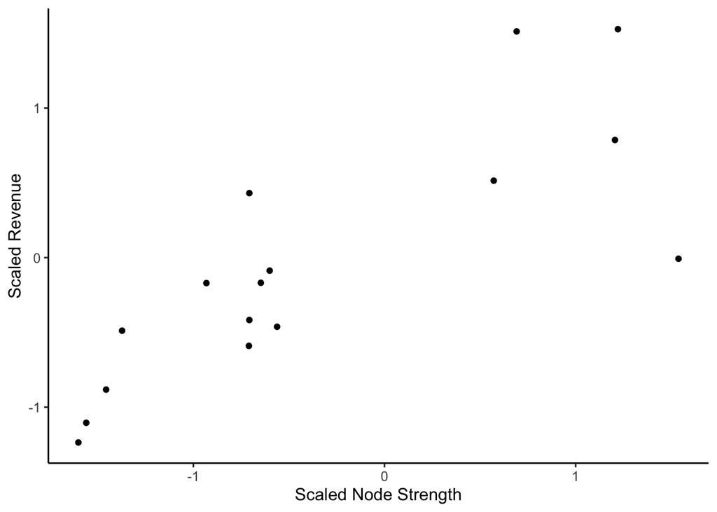

```r
ggplot(plotdat_wide) +
  geom_point(aes(x=`Scaled Node Strength`, y=`Scaled Revenue`)) +
  theme_classic2()
```

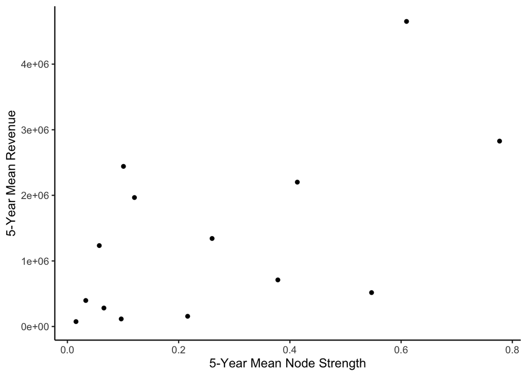

```r
ggplot(plotdat_wide) +
  geom_point(aes(x=`5-Year Mean Node Strength`, y=`5-Year Mean Revenue`)) +
  theme_classic2()
```

```r
vars.corrs <- plotdat_wide %>% ungroup() %>%
  dplyr::select(-(1:2)) %>%
  cor(use="complete.obs") %>%
  as_tibble(rownames="var1") %>%
  pivot_longer(-var1,names_to = "var2",values_to = "corr")

vars.corrs %>% filter(corr !=1) %>% distinct(corr,.keep_all = T) %>% arrange(desc(corr)) %>% knitr::kable() #slice(1:15) %>%
```

| var1 | var2 | corr |
| --- | --- | --- |
| 5-Year Mean Node Strength | 5-Year Mean Importance | 0.9760772 |
| 5-Year Mean Scaled Revenue | 5-Year Mean Scaled Landed Weight | 0.9749260 |
| 5-Year Mean Landed Weight | Long-term Mean Landed Weight | 0.9717415 |
| Long-term Mean Node Strength | Long-term Mean Importance | 0.9668163 |
| Scaled Revenue | Scaled Landed Weight | 0.9556185 |
| Importance | 5-Year Mean Scaled Revenue | 0.9458145 |
| Node Strength | Importance | 0.9274644 |
| Long-term Mean Node Strength | 5-Year Mean Node Strength | 0.9258171 |
| Importance | Scaled Node Strength | 0.9258075 |
| Importance | 5-Year Mean Scaled Landed Weight | 0.9214592 |
| Node Strength | 5-Year Mean Node Strength | 0.9191629 |
| Landed Weight | Long-term Mean Revenue | 0.9188137 |
| Scaled Node Strength | Scaled Importance | 0.9082825 |
| Long-term Mean Importance | 5-Year Mean Importance | 0.9015774 |
| 5-Year Mean Node Strength | Long-term Mean Importance | 0.8959802 |
| Long-term Mean Edge Density | 5-Year Mean Edge Density | 0.8937584 |
| Node Strength | 5-Year Mean Importance | 0.8900421 |
| Scaled Node Strength | 5-Year Mean Scaled Revenue | 0.8855422 |
| Long-term Mean Node Strength | 5-Year Mean Importance | 0.8833779 |
| Importance | Scaled Importance | 0.8793919 |
| Scaled Node Strength | 5-Year Mean Scaled Landed Weight | 0.8776120 |
| Revenue | 5-Year Mean Revenue | 0.8766006 |
| Node Strength | 5-Year Mean Scaled Revenue | 0.8627865 |
| 5-Year Mean Landed Weight | Long-term Mean Revenue | 0.8547091 |
| Scaled Importance | 5-Year Mean Scaled Revenue | 0.8501292 |
| Node Strength | 5-Year Mean Scaled Landed Weight | 0.8447598 |
| Scaled Importance | 5-Year Mean Scaled Landed Weight | 0.8374884 |
| Importance | Scaled Revenue | 0.8351786 |
| Edge Density | 5-Year Mean Edge Density | 0.8332638 |
| Scaled Node Strength | Scaled Revenue | 0.8316992 |

[output cut: 201 more lines]

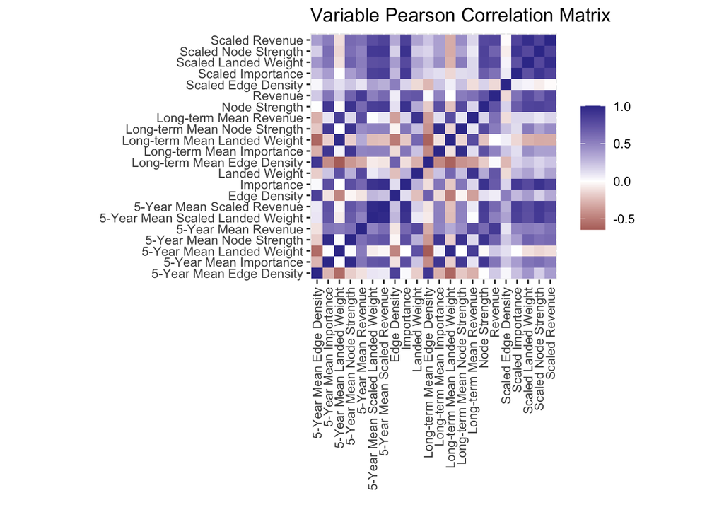

```r
vars.corrs %>%
  ggplot(aes(var1,var2,fill=corr))+
  geom_tile()+
  coord_equal()+
  scale_fill_gradient2()+
  labs(x="",y="",title="Variable Pearson Correlation Matrix",fill="")+
  theme(axis.text.x = element_text(angle=90,vjust=0.5,hjust=1))
```

Long-term mean edge density and edge density are not highly correlated with scaled revenue, scaled importance, or scaled node strength (rho <= 0.3).

Scaled revenue and scaled importance, and scaled revenue and scaled node strength, are highly correlated (rho >0.7).

Therefore, we should simplify the plot below and focus on a 2D figure. Because revenue is more intuitive than the network metrics Importance and Node Strength, we drop them.

## Scaled plot, single year anomaly for economic dependence

We define a port group that is especially vulnerable to declines in the salmon fishery in 2021-2022, relative to the period 2004-2021, as one that has: - salmon revenue in 2020-2021 that is higher than its long-term average, indicating relatively high economic dependence on the salmon fishery, - a low long-term average resilience (or adaptive capacity) index value (where lower resilience corresponds to lower than average connectivity among fisheries based on fisheries participation networks for each port group). This approach is consistent with definitions of social vulnerability in the literature (e.g., Thiault et al. 2019).

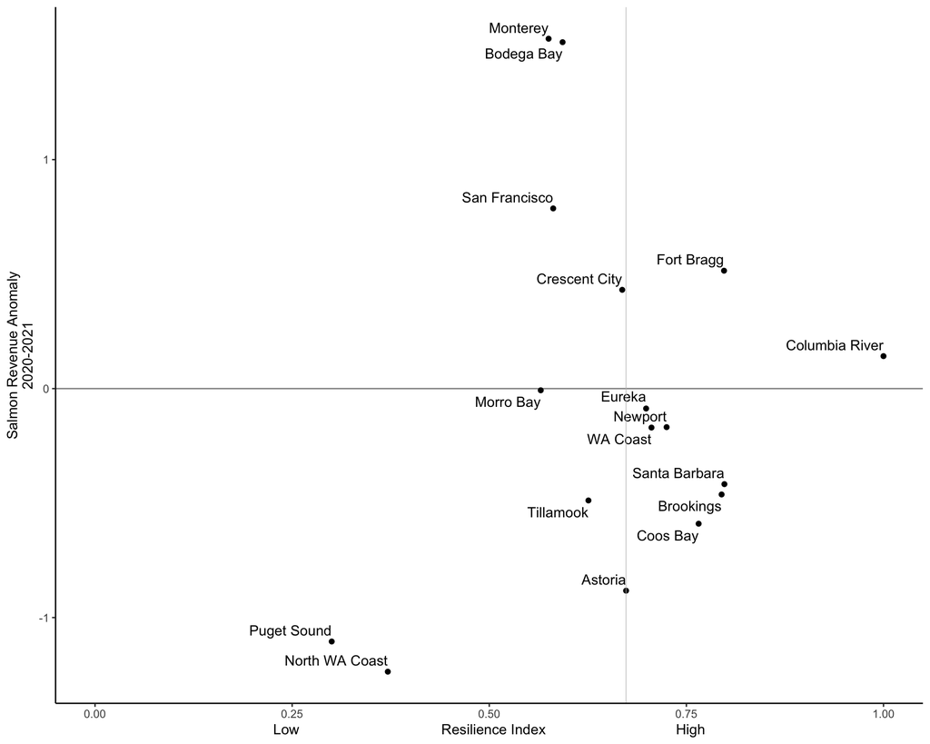

In the plot above, points in the upper left quadrant indicate IOPAC port groups that would be most vulnerable to declines in the salmon fishery following the 2020-2021 fishing season (e.g., Bodega Bay, Monterey), while points in the lower right quadrant indicate IOPAC port groups that would be least vulnerable (e.g., Brookings, Santa Barbara). Port groups with higher economic dependence on salmon and higher resilience (points in the top right quadrant such as Fort Bragg and Columbia River) have greater potential for adaptation, while those with lower economic dependence on salmon and lower adaptive capacity (points in the lower left quadrant such as Puget Sound and the North WA Coast) have high latent risk.

In general, we see that for most port groups in 2020-2021 economic dependence on salmon was not very different from the long-term averages (most points on the y-axis are within +/- 1 SD).

The x-axis, a resilience index based on Edge Density, is a statistic derived from the fisheries participation network for each IOPAC port group. Edge Density is calculated as the ratio of the number of edges present to the total possible edges in the network, and represents the extent to which nodes within a network are connected by vessels that participate in multiple fisheries. Higher Edge Densities correspond to greater flexibility in fishery participation among all vessels represented in the network. Note that Edge Density scales with network size (it is easier to achieve a high density in a low complexity network), so comparisons across networks of different sizes should be interpreted carefully. With that caveat in mind, declines in Edge Density imply a simplification of network structure, which can in turn reduce resilience to environmental or regulatory shocks because of diminished flexibility to participate in other fisheries in the same port group (e.g., Fisher et al. 2021). Here we have calculated the long-term average Edge Density from 2004-2021 for each port group.

The y-axis, Salmon Revenue, reflects the aggregate ex-vessel value of salmon landed in each IOPAC port group. Here we have standardized Salmon Revenue relative to each port group’s long-term mean value to accentuate differences in the 2020-2021 season. We note that this Salmon Revenue Anomaly is positively correlated with statistics from fisheries participation networks that describe how well the salmon fishery is connected to other fisheries in the network.

Grey lines on the x- and y-axes in this plot are for reference only. On the y-axis, this line corresponds to no difference from the long-term mean revenue for each port group. On the x-axis, this line corresponds to the median long-term resilience index across port groups.

This framework was inspired by Figure 4 in: Moore, S.K., Cline, M.R., Blair, K., Klinger, T., Varney, A. & Norman, K. (2019). An index of fisheries closures due to harmful algal blooms and a framework for identifying vulnerable fishing communities on the U.S. West Coast. Marine Policy, 103543. It is congruent with the social vulnerability framework used in Figure 2 (right panel) of Thiault, L., S. Gelcich, N. Marshall, P. Marshall, F. Chlous, and J. Claudet. 2020. Operationalizing vulnerability for social–ecological integration in conservation and natural resource management. Conservation Letters 13:e12677. https://conbio.onlinelibrary.wiley.com/doi/abs/10.1111/conl.12677

## Scaled plot, moving average for economic dependence and edge density

We define a port group that is especially vulnerable to declines in the salmon fishery in 2021-2022, relative to the period 2004-2021, as one that has: - high average salmon revenue from 2016-2021, indicating relatively high economic dependence on the salmon fishery over the last 5 years, - a low 5-year average resilience (or adaptive capacity) index value (where lower resilience corresponds to lower than average connectivity among fisheries based on fisheries participation networks for each port group). This approach is consistent with definitions of social vulnerability in the literature (e.g., Thiault et al. 2019).

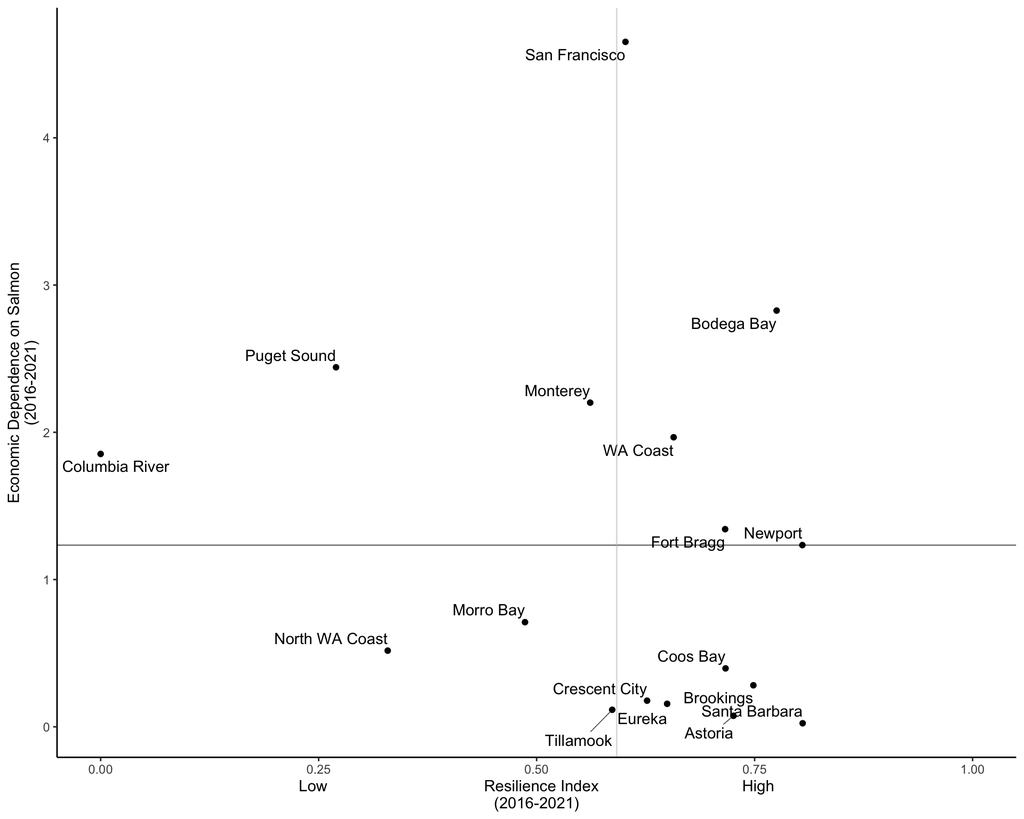

In the plot above, points in the upper left quadrant indicate IOPAC port groups that would be most vulnerable to declines in the salmon fishery following the 2020-2021 fishing season (e.g., Puget Sound, Monterey), while points in the lower right quadrant indicate IOPAC port groups that would be least vulnerable (e.g., Brookings, Santa Barbara). Port groups with higher economic dependence on salmon and higher resilience (points in the top right quadrant such as Bodega Bay) have greater potential for adaptation, while those with lower economic dependence on salmon and lower adaptive capacity (points in the lower left quadrant such as the North WA Coast and Morro Bay) have high latent risk.

In general, we see that economic dependence on salmon from 2016-2021 (y-axis) has been high San Francisco, Bodega Bay, and Puget Sound (among other port groups), and low in Santa Barbara and Astoria (among other port groups). We note that economic dependence on salmon (i.e., salmon revenue) is positively correlated with statistics from fisheries participation networks that describe how well the salmon fishery is connected to other fisheries in the network.

The x-axis, a resilience index based on Edge Density, is a statistic derived from the fisheries participation network for each IOPAC port group. Edge Density is calculated as the ratio of the number of edges present to the total possible edges in the network, and represents the extent to which nodes within a network are connected by vessels that participate in multiple fisheries. Higher Edge Densities correspond to greater flexibility in fishery participation among all vessels represented in the network. Note that Edge Density scales with network size (it is easier to achieve a high density in a low complexity network), so comparisons across networks of different sizes should be interpreted carefully. With that caveat in mind, declines in Edge Density imply a simplification of network structure, which can in turn reduce resilience to environmental or regulatory shocks because of diminished flexibility to participate in other fisheries in the same port group (e.g., Fisher et al. 2021). Here we have calculated the 5-year average Edge Density from 2016-2021 for each port group.

Grey lines on the x- and y-axes in this plot are for reference only. These lines correspond to the mean values across port groups.

This framework was inspired by Figure 4 in: Moore, S.K., Cline, M.R., Blair, K., Klinger, T., Varney, A. & Norman, K. (2019). An index of fisheries closures due to harmful algal blooms and a framework for identifying vulnerable fishing communities on the U.S. West Coast. Marine Policy, 103543. It is congruent with the social vulnerability framework used in Figure 2 (right panel) of Thiault, L., S. Gelcich, N. Marshall, P. Marshall, F. Chlous, and J. Claudet. 2020. Operationalizing vulnerability for social–ecological integration in conservation and natural resource management. Conservation Letters 13:e12677. https://conbio.onlinelibrary.wiley.com/doi/abs/10.1111/conl.12677

# Plot of Salmon-Based Vulnerability and 2 Example Fishery Participation Networks

## Pull in network graphs

Focus on Brookings (higher resilience, lower salmon revenue) and Monterey (lower resilience, higher salmon revenue).

Import png’s

```r
ESRimages_2020 <- list.files(here::here(pngdir_ports), "2020_circular_compare")

img_brookings <- magick::image_read(
  here::here(pngdir_ports,
             ESRimages_2020[grep("Brookings", ESRimages_2020)])
)

img_monterey <- magick::image_read(
  here::here(pngdir_ports,
             ESRimages_2020[grep("Monterey", ESRimages_2020)])
)

img_bodega <- magick::image_read(
  here::here(pngdir_ports,
             ESRimages_2020[grep("Bodega", ESRimages_2020)])
)

img_nwc <- magick::image_read(
  here::here(pngdir_ports,
             ESRimages_2020[grep("North", ESRimages_2020)])
)
```

Make plots and combine

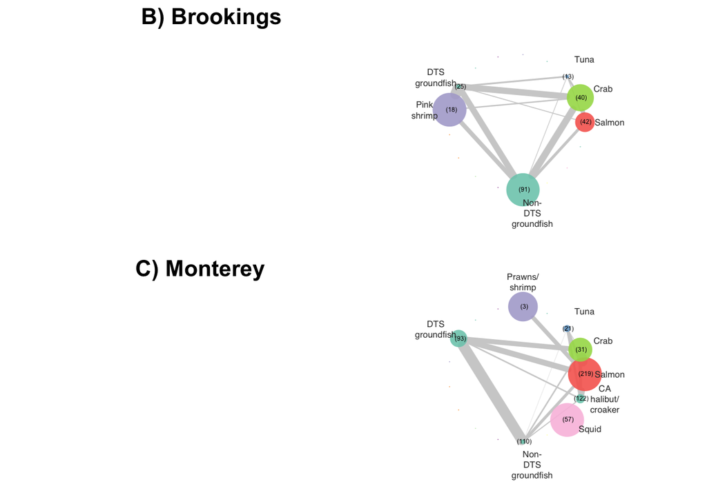

```r
p_brookings_2020 <- ggplot(data.frame(x = 1:2, y = 1:2), aes(x, y)) +
     geom_point(size = 1, colour=NA) +
     draw_image(img_brookings , x = 1, y = 1, scale = 1.1, halign = 0.9) +
     theme_void()

p_monterey_2020 <- ggplot(data.frame(x = 1:2, y = 1:2), aes(x, y)) +
     geom_point(size = 1, colour=NA) +
     draw_image(img_monterey , x = 1, y = 1, scale = 1.1, halign = 0.9) +
     theme_void()

p_2020 <- plot_grid(p_brookings_2020, p_monterey_2020,
                            labels = c('B) Brookings', 'C) Monterey'),
                            label_size = 16, label_x = c(0.1,0.1), label_y = c(1, 1), align = "hv", rel_widths = c(1, 1), ncol = 1
) #label_x = 0.4, c(0.35, 0.35, 0.35, 0.35, 0.35, 0.35)
p_2020
```

Make plots and combine

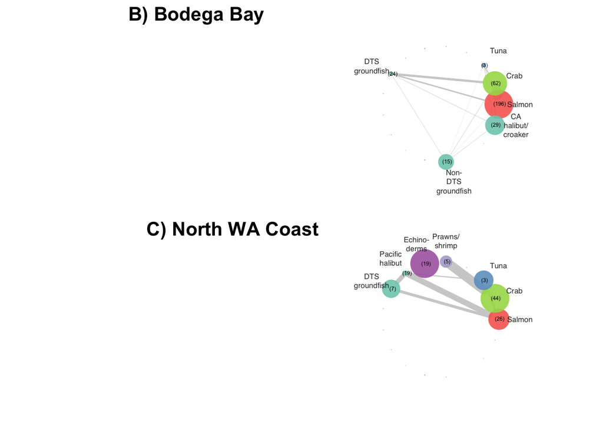

```r
p_bodega_2020 <- ggplot(data.frame(x = 1:2, y = 1:2), aes(x, y)) +
     geom_point(size = 1, colour=NA) +
     draw_image(img_bodega , x = 1, y = 1, scale = 1.1, halign = 0.9) +
     theme_void()

p_nwc_2020 <- ggplot(data.frame(x = 1:2, y = 1:2), aes(x, y)) +
     geom_point(size = 1, colour=NA) +
     draw_image(img_nwc , x = 1, y = 1, scale = 1.1, halign = 0.9) +
     theme_void()

p_2020_bodega_nwc <- plot_grid(p_bodega_2020, p_nwc_2020,
                            labels = c('B) Bodega Bay', 'C) North WA Coast'),
                            label_size = 16, label_x = c(0.1,0.1), label_y = c(1, 1), align = "hv", rel_widths = c(1, 1), ncol = 1
) #label_x = 0.4, c(0.35, 0.35, 0.35, 0.35, 0.35, 0.35)
p_2020_bodega_nwc
```

## Combine vulnerability plot and network graphs

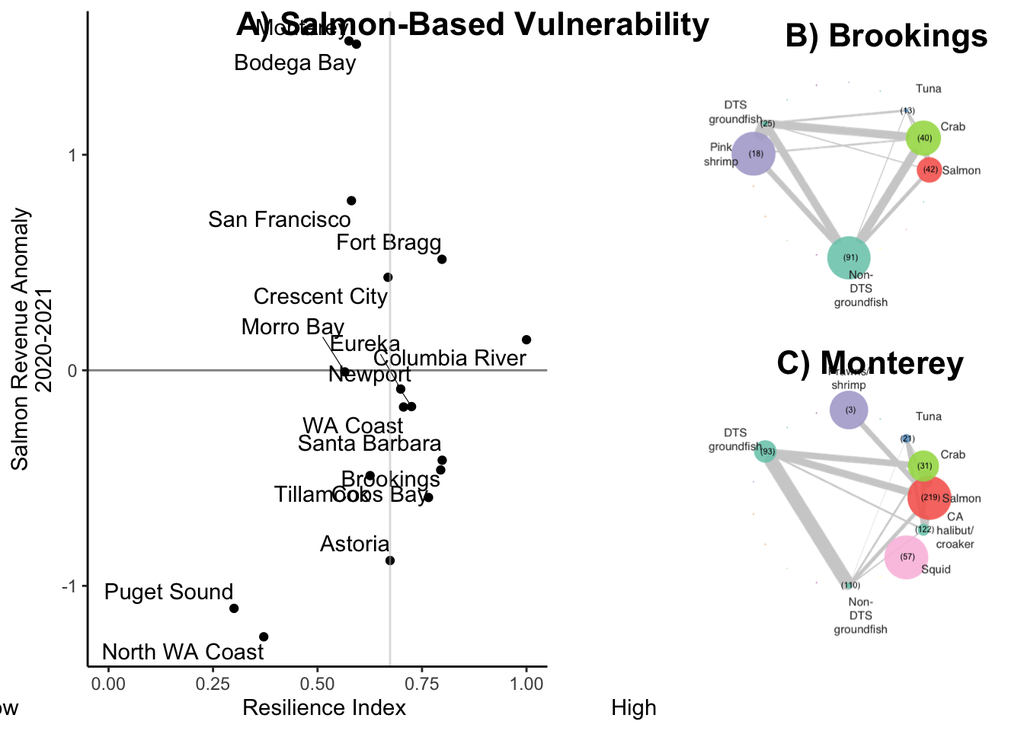

```r
p_all <- plot_grid(fig_scaled, p_2020,
                            labels = c('A) Salmon-Based Vulnerability',''),
                            label_size = 16, label_x = c(0,0.1), label_y = c(1,1), align = "hv", rel_widths = c(1.2, 1), ncol = 2
) #label_x = 0.4, c(0.35, 0.35, 0.35, 0.35, 0.35, 0.35)
p_all
```

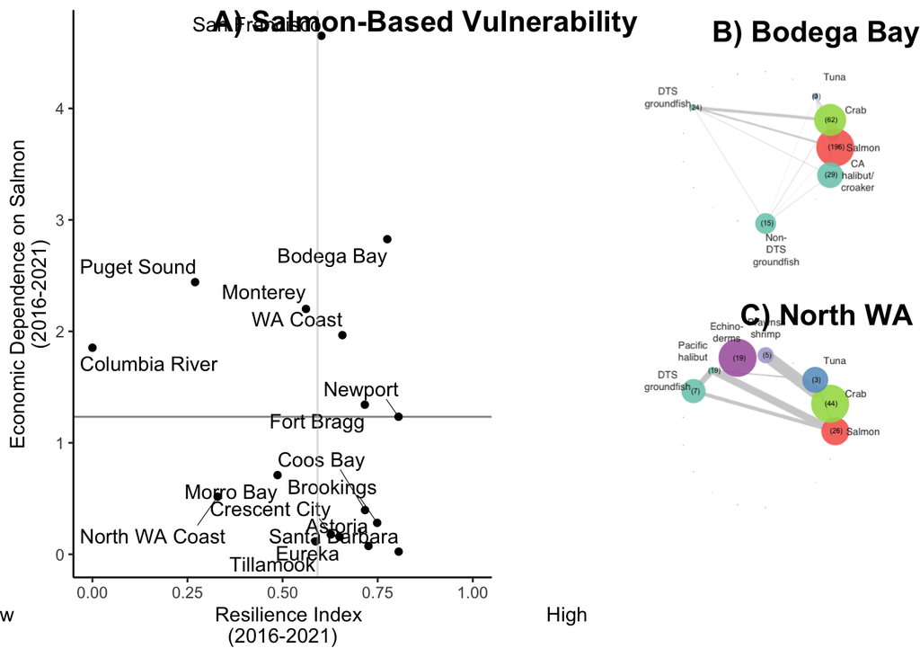

```r
# p_all_ma_scaled <- plot_grid(fig_ma_scaled, p_2020,
#                             labels = c('A) Salmon-Based Vulnerability',''),
#                             label_size = 16, label_x = c(0,0.1), label_y = c(1,1), align = "hv", rel_widths = c(1.2, 1), ncol = 2
# ) #label_x = 0.4, c(0.35, 0.35, 0.35, 0.35, 0.35, 0.35)
# p_all_ma_scaled

p_all_ma <- plot_grid(fig_ma, p_2020_bodega_nwc,
                            labels = c('A) Salmon-Based Vulnerability',''),
                            label_size = 16, label_x = c(0,0.1), label_y = c(1,1), align = "hv", rel_widths = c(1.2, 1), ncol = 2
) #label_x = 0.4, c(0.35, 0.35, 0.35, 0.35, 0.35, 0.35)
p_all_ma
```